# Lab 13 - Survival analysis

Nonparametric statistics ay 2022/2023

2022/11/18

## Loading necessary libraries

```r
library(survival)
library(survminer)
library(dplyr)
library(ggplot2)
library(knitr)
library(broom)
library(tidyr)
```

## A Crash Course in Survival Analysis

Survival analysis is a collection of statistical procedures for data analysis for which the outcome variable of interest is the survival time. `survival` is THE package to perform survival analysis in R, and the core functions we will use include:

- `Surv()`: creates a survival object.
- `survfit()`: fits a survival curve using a formula.
- `survdiff()`: Log-rank test for differences in survival between two or more groups.
- `coxph()`: fits a Cox proportional hazard model.

Today we will work with the lung dataset from the survival package: it is related to patients with advanced lung cancer from the North Central Cancer Treatment Group. Performance scores rate how well the patient can perform usual daily activities. It contains the following variables:

- inst: Institution code
- time: Survival time in days
- status: censoring status 1=censored, 2=dead
- age: Age in years
- sex: Male=1 Female=2
- ph.ecog: ECOG performance score (0=good 5=dead)
- ph.karno: Karnofsky performance score (bad=0-good=100) rated by physician
- pat.karno: Karnofsky performance score as rated by patient
- meal.cal: Calories consumed at meals
- wt.loss: Weight loss in last six months

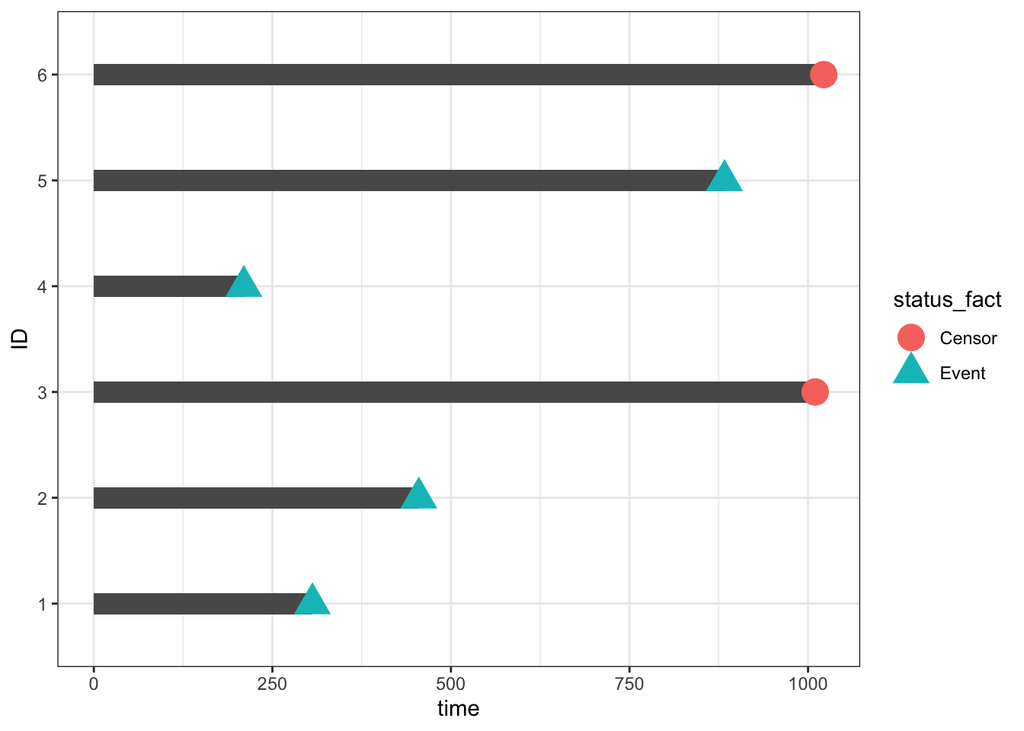

```r
lung$ID <- factor(seq(1:nrow(lung)))
lung$status_fact <- factor(lung$status, labels = (c('Censor', 'Event')))
lung_subs <- head(lung)

ggplot(data=lung_subs,aes(x=ID,y=time)) +
  geom_bar(stat='identity',width=0.2) +
  geom_point(aes(color=status_fact,shape=status_fact),size=6) +
  coord_flip()
```

Let us investigate the survival probability for all the subjects, by gender and by age.

## Survival Object

The function `Surv(time, event)` of the survival package allows to create a survival object, usually used as a response variable in a model formula.

```r
head(Surv(lung$time, lung$status==2))
```

```
## [1]  306   455  1010+  210   883  1022+
```

## Kaplan-Meier estimator for survival curve

The Kaplan-Meier estimator of a survival curve can be computed using the `survfit` function:

```r
fit <- survfit(Surv(time, status==2) ~ 1, data = lung)
```

The function survfit() returns a list of variables including the following components:

- n: total number of subjects
- time: the event time points on the curve $(t=t^*_j)$
- n.risk: the number of subjects at risk at time t
- n.event: the number of events that occurred at time t
- n.censor: the number of censored subjects, who exit the risk set at time t
- surv: the kaplan-meier estimator for survival S(t)
- std.err: the standard error for S(t)
- lower, upper: lower and upper confidence limits for the survival curve S(t), respectively.
- cumhaz: the cumulative hazard curve H(t) = - log(S(t))
- std.chaz: the standard error for H(t)

As usual it is edifying to try and hard code the quantities returned by a function: in this way you can truly validate whether you have understood the considered concepts. The following chunk of R code does so for the quantities returned by `survfit`: we will not comment it, but it could be useful for you to go through it (also for learning some data-wrangling principles based on the [tidyverse](https://www.tidyverse.org)).

```r
df_KM <- lung %>%
  as_tibble() %>%
  select(time, status) %>%
  mutate(status=if_else(status==2,"death", "censored")) %>%
  arrange(time)

df_KM_enriched <- df_KM %>%
  count(time,status,name = "n.event")


n_risk_manual <- numeric(n_distinct(df_KM_enriched$time))
n_censored_manual <- df_KM %>%
  group_by(time) %>%
  summarise(n_censored_manual=sum(status=="censored")) %>%
  pull(n_censored_manual)

n_event_manual <- df_KM %>%
  group_by(time) %>%
  summarise(n_event_manual=sum(status=="death")) %>%
  pull(n_event_manual)

n_risk_manual[1] <- nrow(df_KM)
time_manual <- unique(df_KM_enriched$time)

for(i in 2:length(n_risk_manual)){
  previous_t <- df_KM_enriched %>%
    filter(time==time_manual[i-1])
  n_death_previous_t <- pull(.data = filter(previous_t,status=="death"), n.event)
  n_death_previous_t <- ifelse(length(n_death_previous_t)==0,0,n_death_previous_t)
  n_censored_previous_t <- pull(.data = filter(previous_t,status=="censored"), n.event)
  n_censored_previous_t <- ifelse(length(n_censored_previous_t)==0,0,n_censored_previous_t)
  n_risk_manual[i] <- n_risk_manual[i-1]-n_death_previous_t-n_censored_previous_t
}


df_KM_fit <- distinct(df_KM, time) %>%
  mutate(
    n_risk = n_risk_manual,
    n_censored = n_censored_manual,
    n_event = n_event_manual,
    h_est = (n_event ) / n_risk,
    S_t = cumprod(1 - h_est), # or exp(-cumsum(h_est)) for Nelson-Aalen estimator
    cumhaz=cumsum(h_est) # or -log(S_t)
  )
```

The complete table for Kaplan-Meier estimator can be obtained as follows:

```r
summary(fit)
```

We make it pretty firstly by tidying the results with the broom package (very useful for a variety of models) and then passing it to the kable function from knitr

```r
kable(head(tidy(fit),20))
```

| time | n.risk | n.event | n.censor | estimate | std.error | conf.high | conf.low |
| --- | --- | --- | --- | --- | --- | --- | --- |
| 5 | 228 | 1 | 0 | 0.9956140 | 0.0043956 | 1.0000000 | 0.9870734 |
| 11 | 227 | 3 | 0 | 0.9824561 | 0.0088499 | 0.9996460 | 0.9655619 |
| 12 | 224 | 1 | 0 | 0.9780702 | 0.0099167 | 0.9972662 | 0.9592437 |
| 13 | 223 | 2 | 0 | 0.9692982 | 0.0117865 | 0.9919508 | 0.9471630 |
| 15 | 221 | 1 | 0 | 0.9649123 | 0.0126289 | 0.9890941 | 0.9413217 |
| 26 | 220 | 1 | 0 | 0.9605263 | 0.0134255 | 0.9861367 | 0.9355811 |
| 30 | 219 | 1 | 0 | 0.9561404 | 0.0141842 | 0.9830945 | 0.9299253 |
| 31 | 218 | 1 | 0 | 0.9517544 | 0.0149107 | 0.9799794 | 0.9243423 |
| 53 | 217 | 2 | 0 | 0.9429825 | 0.0162849 | 0.9735659 | 0.9133598 |
| 54 | 215 | 1 | 0 | 0.9385965 | 0.0169391 | 0.9702809 | 0.9079467 |
| 59 | 214 | 1 | 0 | 0.9342105 | 0.0175747 | 0.9669508 | 0.9025788 |
| 60 | 213 | 2 | 0 | 0.9254386 | 0.0187982 | 0.9601711 | 0.8919624 |
| 61 | 211 | 1 | 0 | 0.9210526 | 0.0193892 | 0.9567281 | 0.8867075 |
| 62 | 210 | 1 | 0 | 0.9166667 | 0.0199681 | 0.9532533 | 0.8814843 |
| 65 | 209 | 2 | 0 | 0.9078947 | 0.0210939 | 0.9462168 | 0.8711247 |
| 71 | 207 | 1 | 0 | 0.9035088 | 0.0216426 | 0.9426590 | 0.8659845 |
| 79 | 206 | 1 | 0 | 0.8991228 | 0.0221830 | 0.9390770 | 0.8608685 |
| 81 | 205 | 2 | 0 | 0.8903509 | 0.0232410 | 0.9318456 | 0.8507039 |
| 88 | 203 | 2 | 0 | 0.8815789 | 0.0242726 | 0.9245323 | 0.8406212 |
| 92 | 201 | 1 | 1 | 0.8771930 | 0.0247797 | 0.9208475 | 0.8356080 |

The median survival times represents the time at which the survival probability, S(t), is 0.5.

```r
surv_median(fit)
```

| strata | median | lower | upper |
| --- | --- | --- | --- |
| All | 310 | 285 | 363 |

Or, manually

```r
median_St<-fit$time[fit$surv<=0.5][1]
median_St
```

```
## [1] 310
```

### Kaplan-Meier plots

To plot the KM estimator you can use the function plot

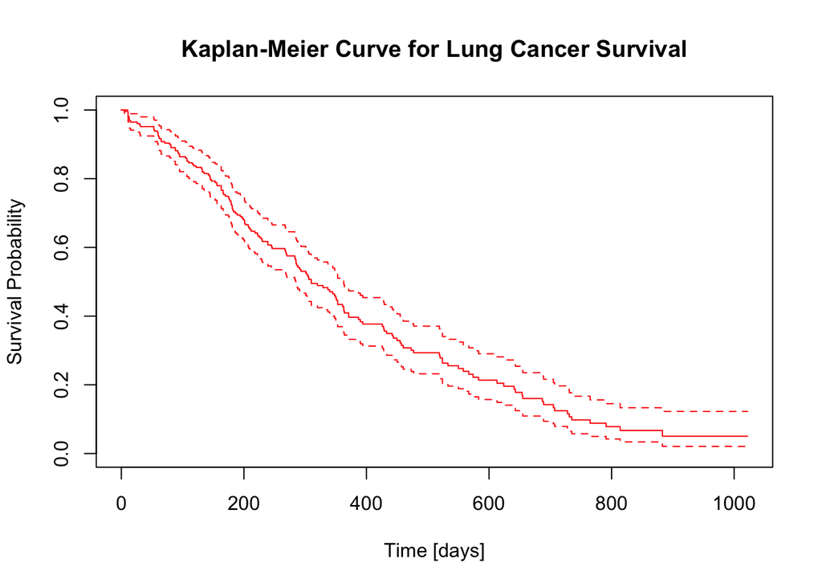

```r
plot(fit, conf.int = T, xlab='Time [days]', ylab = 'Survival Probability', col='red',
     main="Kaplan-Meier Curve for Lung Cancer Survival")
```

For a better visualization we can use the `ggsurvplot()` function from the survminer package:

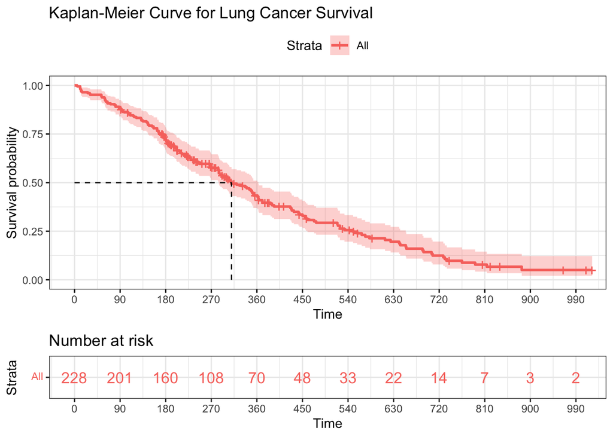

```r
ggsurvplot(fit,
           risk.table = TRUE, # Add risk table
           risk.table.col = "strata", # Change risk table color by groups
           surv.median.line = "hv", # Specify median survival
           ggtheme = theme_bw(), # Change ggplot2 theme
           break.time.by=90,
           title="Kaplan-Meier Curve for Lung Cancer Survival")
```

The cumulative incidence, or cumulative failure probability (CFP), shows the cumulative probabilities of experiencing the event of interest and it is computed as
$$CFP(t) =
P(T<t),$$
so it can be estimated as:
$$1-S(t)$$

```r
cumulative_incidence <- 1 - fit$surv
```

We can visualize it using again the `ggsurvplot()` function specifying the option fun=‘event’

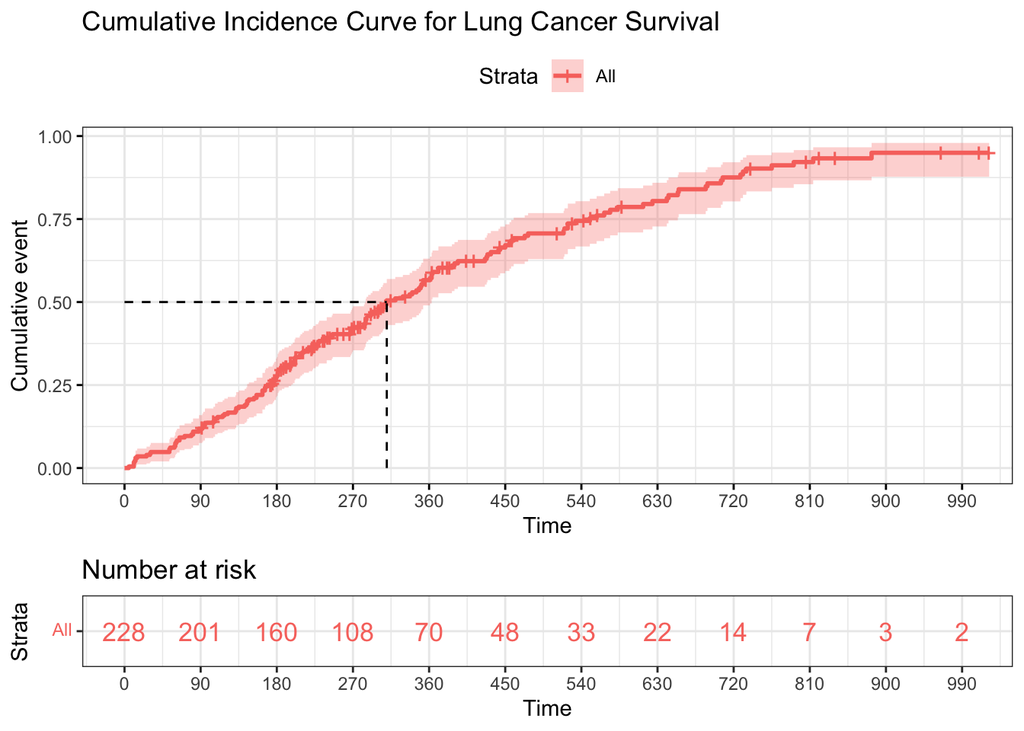

```r
ggsurvplot(fit,
           risk.table = TRUE, # Add risk table
           risk.table.col = "strata", # Change risk table color by groups
           surv.median.line = "hv", # Specify median survival
           ggtheme = theme_bw(), # Change ggplot2 theme
           break.time.by=90,
           fun='event',
           title="Cumulative Incidence Curve for Lung Cancer Survival")
```

We may also want to plot the cumulative hazard; it is defined as
$$H(t) = -log(S(t))$$
The cumulative hazard $H(t)$ can be interpreted as the cumulative force of mortality. In other words, it measures the total amount of risk that has been accumulated up to time $t$.

The cumulative hazard is computed by the function `survfit()` using the Nelson-Aalen cumulative hazard rate estimator and it is given by:

```r
H <- fit$cumhaz
```

Again we can easily plot it:

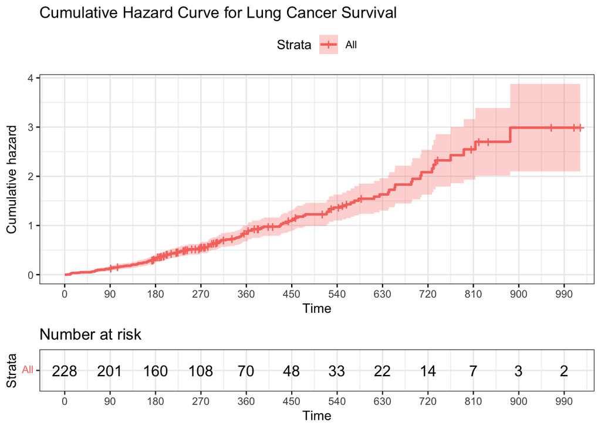

```r
ggsurvplot(fit,
           risk.table = TRUE, # Add risk table
           ggtheme = theme_bw(), # Change ggplot2 theme
           break.time.by=90,
           fun='cumhaz',
           title="Cumulative Hazard Curve for Lung Cancer Survival")
```

### Kaplan-Meier Curves between groups

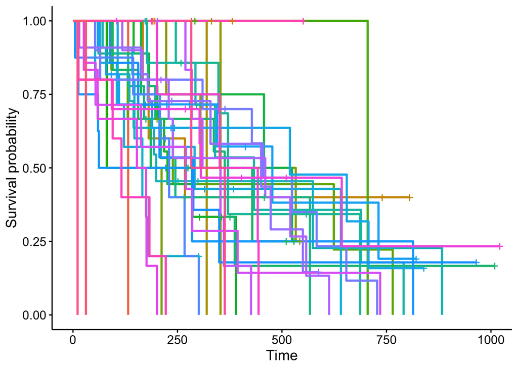

```r
fit.age <- survfit(Surv(time, status) ~ age, data=lung)
ggsurvplot(fit.age, conf.int = F, risk.table.col = "strata", legend='none')
```

We cannot just do this, because we will get a separate curve for every unique value of age! We have to categorize data in some way.

One thing we might do is to categorize a continuous variable into different groups (this clearly works much better for variables that are already categorical, more on this problem later). Let us start by plotting a histogram showing the distribution of age.

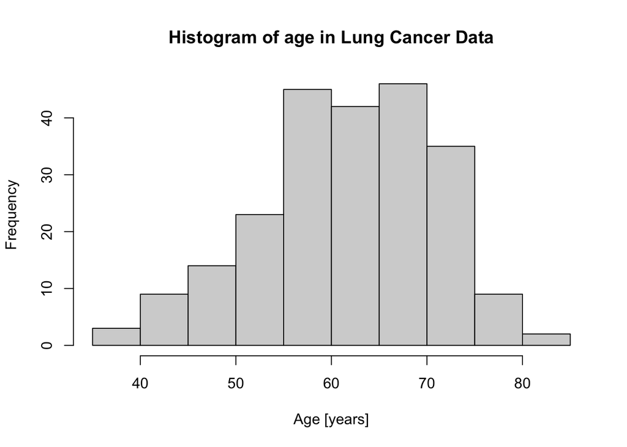

```r
hist(lung$age, xlab='Age [years]', main='Histogram of age in Lung Cancer Data')
```

```r
summary(lung$age)
```

```
##    Min. 1st Qu.  Median    Mean 3rd Qu.    Max.
##   39.00   56.00   63.00   62.45   69.00   82.00
```

Let us create a categorical variable with cut point at $70$ and +Infinity (no upper limit), labeling as ‘young’ subjects with age less or equal than 70 and as ‘old’ subject aged more than 70.

```r
lung$agecat70 <- cut(lung$age, breaks=c(0, 70, Inf), labels=c("young", "old"))
```

What happens when we make a KM plot with this new categorization?

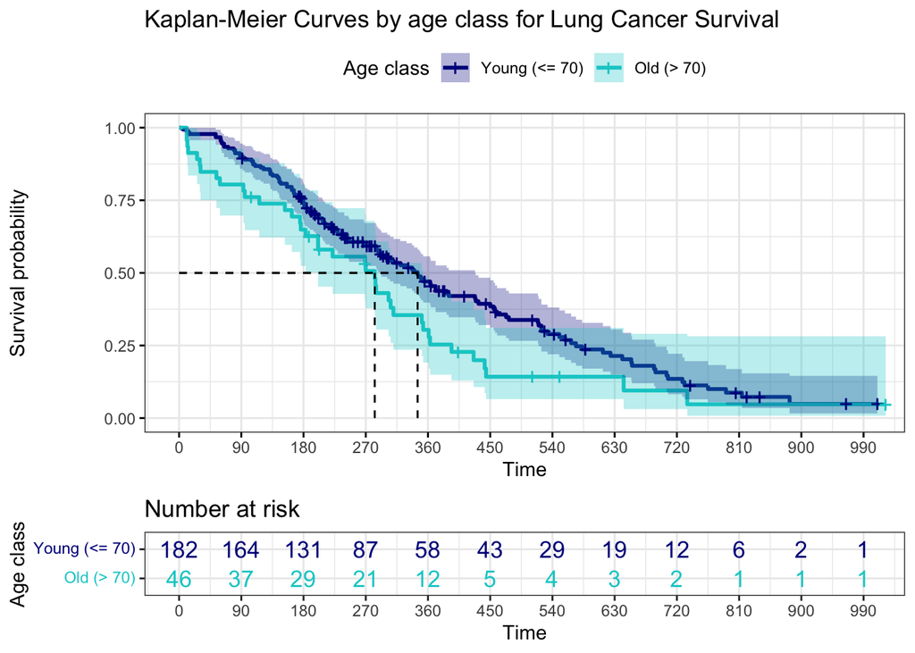

```r
fit.age <- survfit(Surv(time, status) ~ agecat70, data=lung)
ggsurvplot(fit.age, conf.int = T,
           risk.table = TRUE, # Add risk table
           risk.table.col = "strata", # Change risk table color by groups
           surv.median.line = "hv", # Specify median survival
           ggtheme = theme_bw(), # Change ggplot2 theme
           break.time.by=90,
           legend.labs=c("Young (<= 70)","Old (> 70)"), legend.title="Age class",
           palette=c("darkblue","cyan3"),
           title="Kaplan-Meier Curves by age class for Lung Cancer Survival")
```

It looks like there’s some differences in the curves between “old” and “young” patients, with older patients having slightly worse survival odds. Is there statistical evidence for that difference?

```r
log_rank_test <- survdiff(Surv(time, status) ~ agecat70, data=lung)
log_rank_test
```

```
## Call:
## survdiff(formula = Surv(time, status) ~ agecat70, data = lung)
##
##                  N Observed Expected (O-E)^2/E (O-E)^2/V
## agecat70=young 182      127    137.3     0.773      4.64
## agecat70=old    46       38     27.7     3.829      4.64
##
##  Chisq= 4.6  on 1 degrees of freedom, p= 0.03
```

$p=0.03$, the difference in survival between those younger than 70 and older than 70 is significant. Again, with a little bit of data wrangling we can manually compute the required quantities for the log-rank test statistics:

```r
fit_KM_by_agecut <- survfit(Surv(time, status) ~ agecat70, data=lung)
tidy_km <- broom::tidy(fit_KM_by_agecut)

log_rank_calculation_long <- tidy_km %>%
  select(time,strata,n.risk,n.event,n.censor) %>%
  complete(time, strata,fill = list(n.event=0,n.censor=0)) %>%
  group_by(strata) %>%
  fill(n.risk,.direction = "updown") %>%
  group_by(time, strata) %>%
  summarise(d_kj=sum(n.event), n_kj=sum(n.risk)) %>%
  ungroup() %>%
  add_count(time, wt = d_kj,name = "d_j") %>%
  add_count(time, wt = n_kj,name = "n_j") %>%
  group_by(time,strata) %>%
  summarise(e_kj=d_j*n_kj/n_j, d_kj=d_kj)

log_rank_manual <- log_rank_calculation_long %>%
  group_by(strata) %>%
  summarise(Observed=sum(d_kj), Expected=sum(e_kj)) %>%
  mutate(`(O-E)^2/E`=(Observed-Expected)^2/Expected)

log_rank_manual
```

| strata | Observed | Expected | (O-E)^2/E |
| --- | --- | --- | --- |
| agecat70=old | 38 | 27.70103 | 3.8290533 |
| agecat70=young | 127 | 137.29897 | 0.7725384 |

### Exercise

Would we get the same results if we considered as cut point the median of age?

## Hazard Ratio

From the output of the log-rank test we can extract the number of observed and expected deaths in the groups of younger than 70 and older than 70:

- observed deaths in young: 127
- expected deaths in young: 137.3
- observed deaths in old: 38
- expected deaths in old: 27.7

Therefore, the death hazard ratio of young vs old is:

```r
hazard_ratio <- (log_rank_test$obs[1]/log_rank_test$exp[1])/(log_rank_test$obs[2]/log_rank_test$exp[2])
hazard_ratio
```

```
## [1] 0.6742932
```

$HR = 0.674 < 1$ indicating that the risk of deaths in younger than 70 years old is 0.674 times the risk in older than 70: being young is a protective factor.

The log-rank test on the Kaplan-Meier plot can change depending on how you categorize your continuous variable. Indeed, with the log-rank test we are asking: “Are there differences in survival between those younger than 70 and those older than 70 years old?”

If we want to investigate the effect of continuous age on survival, without depending on how we categorize the variable, we have to use a survival model, which analyzes the continuous variable over the whole range of its distribution. A survival regression model is asking: “What is the effect of the variable on survival?”.

### Exercise

Build and comment Kaplan-Meier curves by gender and age.

## Cox model

The Cox proportional-hazards model (Cox, 1972) is essentially a regression model, commonly used in statistical medical research, for investigating the association between the survival time of patients and one or more predictor variables.

In the previous section, we described the basic concepts of survival analyses and methods for analyzing and summarizing survival data, including:

- the definition of hazard and survival functions,
- the construction of Kaplan-Meier survival curves for different patient groups
- the logrank test for comparing two or more survival curves

The Kaplan-Meier curves and logrank tests are examples of univariate analysis. They describe the survival according to one factor under investigation, but they ignore the impact of any other predictor. Additionally, Kaplan-Meier curves and logrank tests are more useful when the predictor variable is categorical (e.g.: treatment A vs treatment B; males vs females). They do not work easily for quantitative predictors such as gene expression, weight, or age.

An alternative method is the Cox proportional hazards regression analysis, which works for both quantitative predictor variables and for categorical variables. Furthermore, the Cox regression model extends survival analysis methods to assess simultaneously the effect of several risk factors on survival time.

The function `coxph()` in the survival package can be used to compute the Cox proportional-hazards regression model in R.

The simplified format is as follow:

```r
coxph(formula, data, method)
```

where

- formula: linear model with a survival object as the response variable. Survival object is created using the function Surv(time, event)
- data: a data frame containing the variables
- method: is used to specify how to handle ties (we would not deal with this problem here)

Let us consider the continuous variable age and fit a univariate Cox regression model

```r
cox.age <- coxph(Surv(time, status) ~ age, data = lung)
cox.age
```

```
## Call:
## coxph(formula = Surv(time, status) ~ age, data = lung)
##
##         coef exp(coef) se(coef)     z      p
## age 0.018720  1.018897 0.009199 2.035 0.0419
##
## Likelihood ratio test=4.24  on 1 df, p=0.03946
## n= 228, number of events= 165
```

As usual, the function `summary()` produces a more complete report:

```r
summary(cox.age)
```

```
## Call:
## coxph(formula = Surv(time, status) ~ age, data = lung)
##
##   n= 228, number of events= 165
##
##         coef exp(coef) se(coef)     z Pr(>|z|)
## age 0.018720  1.018897 0.009199 2.035   0.0419 *
## ---
## Signif. codes:  0 '***' 0.001 '**' 0.01 '*' 0.05 '.' 0.1 ' ' 1
##
##     exp(coef) exp(-coef) lower .95 upper .95
## age     1.019     0.9815     1.001     1.037
##
## Concordance= 0.55  (se = 0.025 )
## Likelihood ratio test= 4.24  on 1 df,   p=0.04
## Wald test            = 4.14  on 1 df,   p=0.04
## Score (logrank) test = 4.15  on 1 df,   p=0.04
```

The Cox regression results can be interpreted as follows:

1. STATISTICAL SIGNIFICANCE The column marked “z” gives the Wald statistic value. It corresponds to the ratio of each regression coefficient to its standard error (z = coef/se(coef)). The wald statistic evaluates whether the beta coefficient of a given variable is statistically significantly different from 0. From the output above, we can conclude that the variable age is statistically significant at 5%.
2. THE REGRESSION COEFFICIENTS The second feature to note is the the sign of the regression coefficients (coef). A positive sign means that the hazard (risk of death) is higher, and thus the prognosis is worse, for subjects with higher values of that variable. The beta coefficient for age = 0.0187 indicates that younger patients have lower risk of death (higher survival rates) than elder ones.
3. HAZARD RATIO & CONFIDENCE INTERVAL The exponentiated coefficients (exp(coef) = exp(0.0187) = 1.019), also known as hazard ratios, give the effect size of covariates. For example, the increase of 1 unit (1 year) in the age increase the hazard of 1.9%. The summary output also gives upper and lower 95% confidence intervals for the hazard ratio (exp(coef)), lower 95% bound = 1.001, upper 95% bound = 1.037. Being younger is associated with good prognostic. Similarly, the increase of 10 units (10 years) in the age increase the hazard of a factor exp(0.0187*10)=1.2056, or 20.5%.
4. GLOBAL STATISTICAL SIGNIFICANCE OF THE MODEL Finally, the output gives p-values for three alternative tests for overall significance of the model: the likelihood-ratio test, the Wald test, and the score logrank statistic. These three methods are asymptotically equivalent. For large enough N, they will give similar results. For small N, they may differ somewhat. The Likelihood ratio test has better behavior for small sample sizes, so it is generally preferred.

### Visualizing the estimated distribution of survival times

Having fitted a Cox model to the data, it’s possible to visualize the predicted survival proportion at any given point in time for a particular risk group. The function survfit() estimates the survival proportion, by default at the mean values of covariates.

Plot the baseline survival function S_0(t)

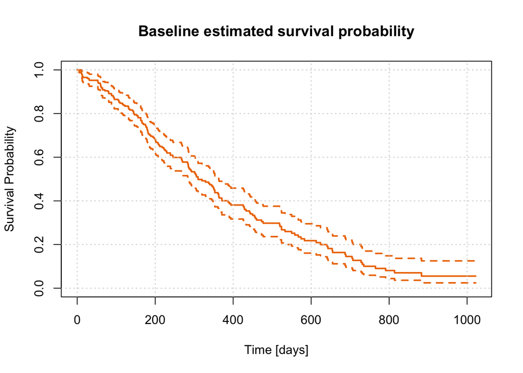

```r
plot(survfit(cox.age, data=lung),
     col="darkorange2", lwd=2, lty=1,
     xlab='Time [days]', ylab='Survival Probability',
     main='Baseline estimated survival probability')
grid()
```

We may wish to display how estimated survival depends upon the value of the covariates of interest. For istance, we want to assess the impact of the age on the estimated survival probability. In this case, we construct a new data frame with $M$ rows, one for each different value of age we are interested in (usually 2 or 3).

Suppose we want to consider ages equal to 50, 65 and 80. We create the new data:

```r
age_df <- with(lung,
               data.frame(age = c(50,65,80) )
)
```

This data frame is passed to survfit() via the newdata argument to estimate survival:

```r
fit.age <- survfit(cox.age, newdata = age_df)
fit.age
```

```
## Call: survfit(formula = cox.age, newdata = age_df)
##
##     n events median 0.95LCL 0.95UCL
## 1 228    165    364     306     524
## 2 228    165    305     270     353
## 3 228    165    245     189     350
```

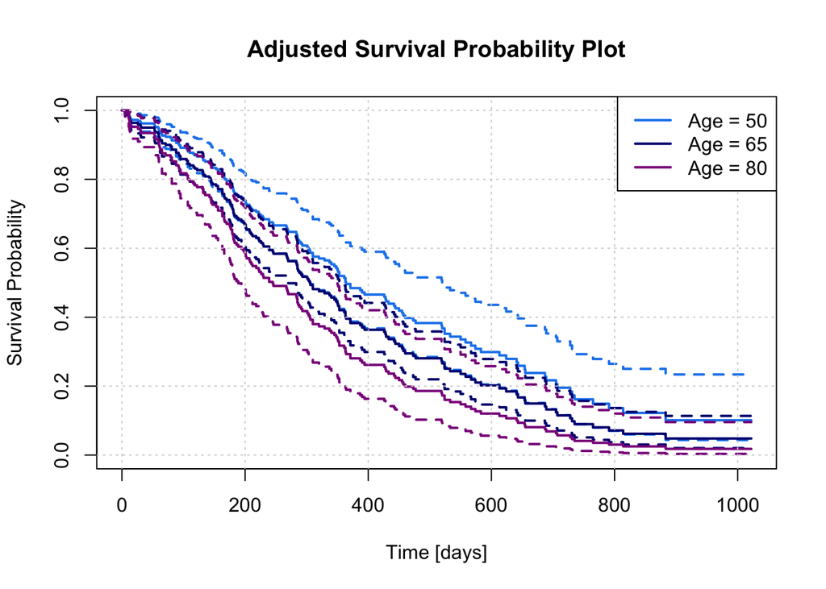

```r
plot(fit.age, conf.int=T,
     col=c("dodgerblue2","navy","darkmagenta"), lwd=2, lty=1,
     xlab='Time [days]', ylab='Survival Probability',
     main='Adjusted Survival Probability Plot')
grid()
legend('topright', c("Age = 50", "Age = 65", "Age = 80"),
       lty=c(1,1,1), lwd=c(2,2,2), col=c("dodgerblue2","navy","darkmagenta"))
```

## Multivariate Cox regression

We want now to describe how different factors jointly impact on survival. To answer to this question, we will perform a multivariate Cox regression analysis with covariates age, sex, Karnofsky performance score rated by physician and weight loss. Check if you categorical covariates are considered factors:

```r
glimpse(lung)
```

```
## Rows: 228
## Columns: 13
## $ inst        <dbl> 3, 3, 3, 5, 1, 12, 7, 11, 1, 7, 6, 16, 11, 21, 12, 1, 22, …
## $ time        <dbl> 306, 455, 1010, 210, 883, 1022, 310, 361, 218, 166, 170, 6…
## $ status      <dbl> 2, 2, 1, 2, 2, 1, 2, 2, 2, 2, 2, 2, 2, 2, 2, 2, 2, 2, 2, 2…
## $ age         <dbl> 74, 68, 56, 57, 60, 74, 68, 71, 53, 61, 57, 68, 68, 60, 57…
## $ sex         <dbl> 1, 1, 1, 1, 1, 1, 2, 2, 1, 1, 1, 2, 2, 1, 1, 1, 1, 1, 2, 1…
## $ ph.ecog     <dbl> 1, 0, 0, 1, 0, 1, 2, 2, 1, 2, 1, 2, 1, NA, 1, 1, 1, 2, 2, …
## $ ph.karno    <dbl> 90, 90, 90, 90, 100, 50, 70, 60, 70, 70, 80, 70, 90, 60, 8…
## $ pat.karno   <dbl> 100, 90, 90, 60, 90, 80, 60, 80, 80, 70, 80, 70, 90, 70, 7…
## $ meal.cal    <dbl> 1175, 1225, NA, 1150, NA, 513, 384, 538, 825, 271, 1025, N…
## $ wt.loss     <dbl> NA, 15, 15, 11, 0, 0, 10, 1, 16, 34, 27, 23, 5, 32, 60, 15…
## $ ID          <fct> 1, 2, 3, 4, 5, 6, 7, 8, 9, 10, 11, 12, 13, 14, 15, 16, 17,…
## $ status_fact <fct> Event, Event, Censor, Event, Event, Censor, Event, Event, …
## $ agecat70    <fct> old, young, young, young, young, old, young, old, young, y…
```

```r
lung$sex <- ifelse(lung$sex==1,'Male','Female')
lung$sex <- as.factor(lung$sex)
```

Fit the Cox’s regression model:

```r
mod.cox <- coxph(Surv(time, status) ~ age + sex + ph.karno + wt.loss, data =  lung)
summary(mod.cox)
```

```
## Call:
## coxph(formula = Surv(time, status) ~ age + sex + ph.karno + wt.loss,
##     data = lung)
##
##   n= 214, number of events= 152
##    (14 observations deleted due to missingness)
##
##               coef exp(coef)  se(coef)      z Pr(>|z|)
## age       0.015140  1.015255  0.009837  1.539  0.12379
## sexMale   0.513955  1.671891  0.174410  2.947  0.00321 **
## ph.karno -0.012871  0.987211  0.006184 -2.081  0.03741 *
## wt.loss  -0.002246  0.997757  0.006357 -0.353  0.72389
## ---
## Signif. codes:  0 '***' 0.001 '**' 0.01 '*' 0.05 '.' 0.1 ' ' 1
##
##          exp(coef) exp(-coef) lower .95 upper .95
## age         1.0153     0.9850    0.9959    1.0350
## sexMale     1.6719     0.5981    1.1878    2.3532
## ph.karno    0.9872     1.0130    0.9753    0.9993
## wt.loss     0.9978     1.0022    0.9854    1.0103
##
## Concordance= 0.643  (se = 0.027 )
## Likelihood ratio test= 18.84  on 4 df,   p=8e-04
## Wald test            = 18.68  on 4 df,   p=9e-04
## Score (logrank) test = 18.99  on 4 df,   p=8e-04
```

The p-values for all three overall tests (likelihood, Wald, and score) are extremely small, indicating that the model is significant. These tests evaluate the omnibus null hypothesis that all of the $\beta$s are 0. In the above example, the test statistics are in close agreement, and the omnibus null hypothesis is soundly rejected.

In the multivariate Cox analysis, the covariates sex and ph.karno are significant (p < 0.05). However, the covariates age and wt.loss fail to be significant.

The HR for sex is exp(coef) = exp(0.514) = 1.67 with 95% CI = [1.19; 2.35]. The hazard ratios of covariates are interpretable as multiplicative effects on the hazard. For example, holding the other covariates constant, being a male increases the hazard by a factor of 1.67, or 67%. We conclude that, being male is associated with bad prognostic.

The HR for ph.karno is exp(coef) = exp(-0.013) = 0.987 with 95% CI = [0.975;0.999], indicating a strong relationship between the ph.karno value and decreased risk of death. Holding the other covariates constant, a higher value of ph.karno is associated with a better survival.

The hazard ratio HR of age is exp(coef) = 1.01, with a 95% CI = [0.996;1.035]. Because the confidence interval for HR includes 1, these results indicate that age makes a smaller contribution to the difference in the HR after adjusting for the other covariates.

Similarly, the hazard ratio HR of wt.loss is exp(coef) = 0.998, with a 95% CI = [0.985;1.010]. Because the confidence interval for HR includes 1, these results indicate that wt.loss makes a smaller contribution to the difference in the HR after adjusting for the other covariates.

### Visualizing Hazard ratios

You can visualize Hr and its CIs using the `ggforest()` function of package survminer:

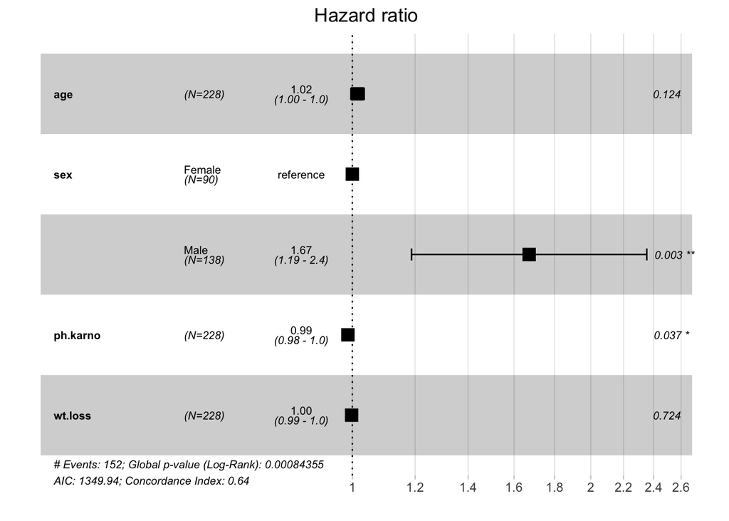

```r
ggforest(mod.cox, data=lung)
```

Plot the baseline survival function $S_0(t)$

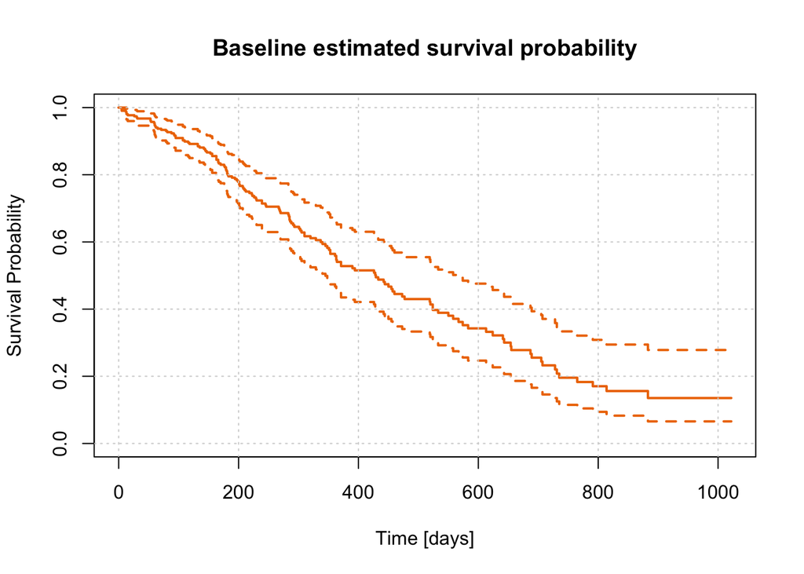

```r
plot(survfit(mod.cox, data=lung),
     col="darkorange2", lwd=2, lty=1,
     xlab='Time [days]', ylab='Survival Probability',
     main='Baseline estimated survival probability')
grid()
```

### Cox Model Assumptions and Goodness of fit

When used inappropriately, statistical models may give rise to misleading conclusions. Therefore, it is important to check that a given model is an appropriate representation of the data.

A first graphical option to check the goodness of fit is to check if the Martingale Residuals

$$M_i=\delta_i-H(t_i, \mathbf{X}_i, \boldsymbol{\beta}), \quad
n=1,\ldots,N$$

with $\delta_i$ 0-1 function indicating whether the $i$-th unit has experienced the event (1 if present, 0 otherwise) and

$$H(t_i, \mathbf{X}_i, \boldsymbol{\beta})=-\log
\left[\hat{S}\left(t_i,\mathbf{X}_i, \boldsymbol{\beta} \right)\right]$$

have $0$ mean along time. Recall that in a Cox model for each patient $i$ the corresponding survival function is estimated with
$$\hat{S}\left(t ,\mathbf{X}_i,
\boldsymbol{\beta}\right)=\left[\hat{S}_{0}(t)\right]^{\exp
\left(\boldsymbol{X}_{i}^{T} \boldsymbol{\beta}\right)}$$

where

$$\hat{S_{0}}(t)=\prod_{j: t_{j}^{*}<t}\left(1-\frac{1}{\sum_{k \in
R\left(t_{j}^{*}\right)} \exp \left(\boldsymbol{X}_{k}^{T}
\hat{\boldsymbol{\beta}}\right)}\right)$$

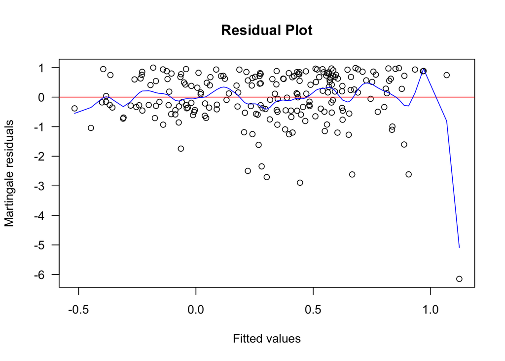

```r
plot(predict(mod.cox), residuals(mod.cox, type='martingale'),
     xlab='Fitted values', ylab='Martingale residuals', main='Residual Plot', las=1)
# Add a line for residual=0
abline(h=0, col='red')
# Fit a smoother for the points
lines(smooth.spline(predict(mod.cox), residuals(mod.cox, type='martingale')), col='blue')
```

Remember to check if you can manually compute the involved quantities:

```r
cox_model_matrix <- model.matrix(mod.cox)
centered_model_matrix <- sweep(cox_model_matrix,MARGIN = 2,STATS = mod.cox$means,FUN = "-")
manual_linear_pred <- c(centered_model_matrix%*%mod.cox$coefficients)
bese_haz_est <- basehaz(mod.cox)

# Martingale residuals
basehaz_for_i <- Vectorize(function(t){
  pos_haz <- which(t<=bese_haz_est$time)[1]
  bese_haz_est$hazard[pos_haz]
})

obs_NA <- which(is.na(lung$wt.loss))
lung_no_NA <- lung[-obs_NA,]
martingale_res_manual <- (lung_no_NA$status-1)- basehaz_for_i(t=lung_no_NA$time)*exp(manual_linear_pred)
```

Alternatively

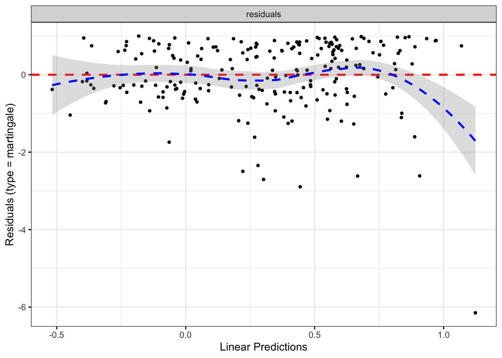

```r
ggcoxdiagnostics(mod.cox, type = "martingale")
```

Sometimes, martingale residuals are difficult to be interpreted. The deviance residual is a normalized transform of the martingale residual:

$$\hat{D}_{i}=\operatorname{sign}\left(M_{i}\right)
\sqrt{-2\left[M_{i}+\delta_{i} \log
\left(\delta_{i}-M_{i}\right)\right]} \quad i=1,\ldots,N$$

These residuals should be roughly symmetrically distributed about zero with a standard deviation of 1.

- Positive values correspond to individuals that “died too soon” compared to expected survival times.
- Negative values correspond to individual that “lived too long”.
- Very large or small values are outliers, which are poorly predicted by the model.

It is also possible to check outliers by visualizing the deviance residuals. Example of deviance residuals:

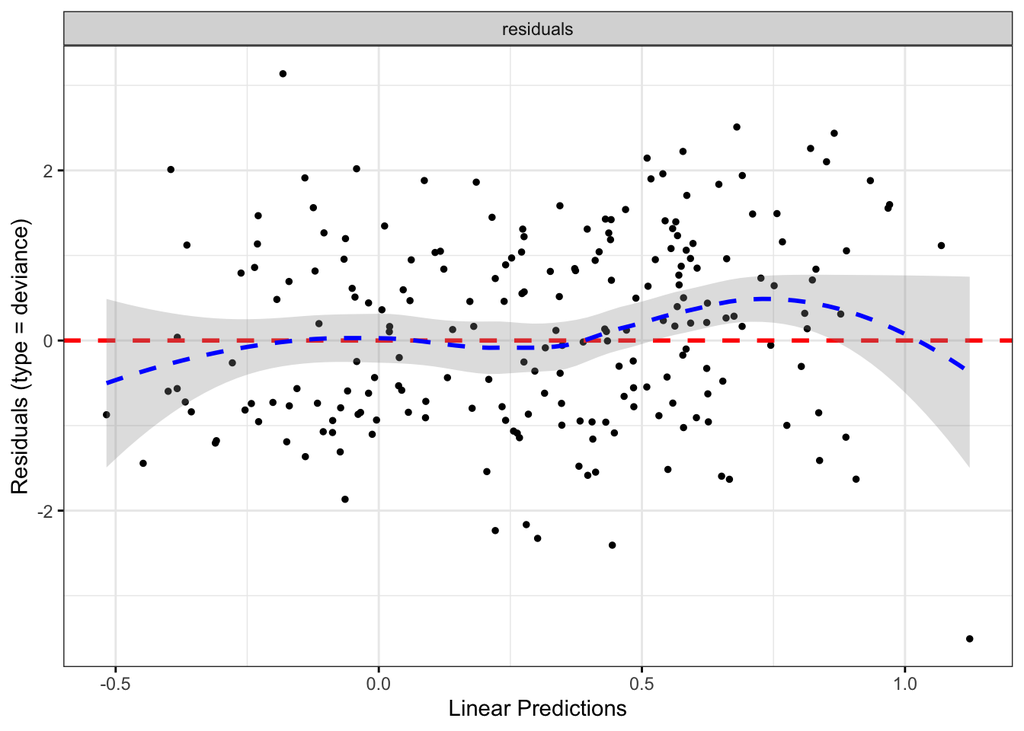

```r
ggcoxdiagnostics(mod.cox, type = "deviance")
```

```r
deviance_res_manual <- sign(martingale_res_manual)*(-2*(martingale_res_manual+(lung_no_NA$status-1)*log((lung_no_NA$status-1)-martingale_res_manual)))^(1/2)
```

The pattern looks fairly symmetric around $0$

A second graphical option could be to use the Schoenfeld residuals to examine model fit and detect outlying covariate values. Shoenfeld residuals represent the difference between the observed covariate and the expected given the risk set at that time. They should be flat, centered about zero. In principle, the Schoenfeld residuals are independent of time. A plot that shows a non-random pattern against time is evidence of violation of the PH assumption.

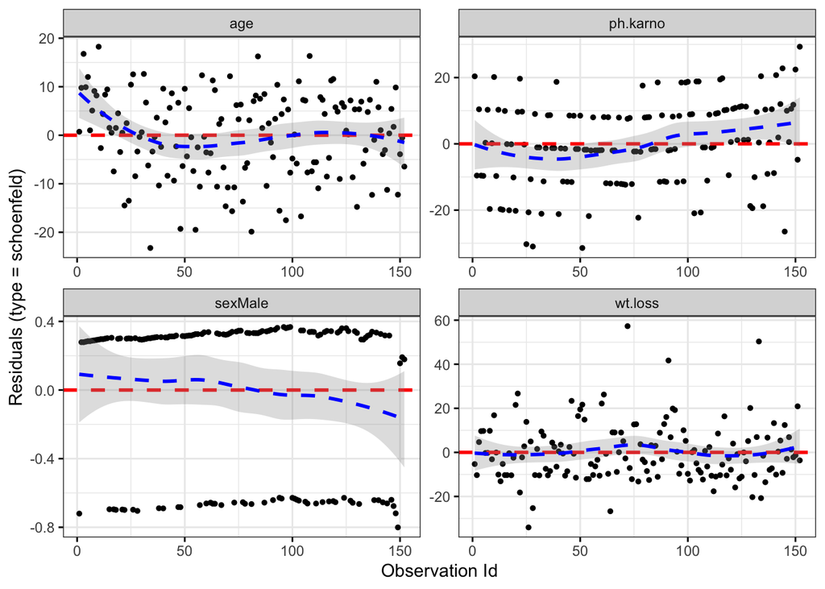

```r
ggcoxdiagnostics(mod.cox, type = "schoenfeld")
```

```r
df_4_schoenfeld <- lung %>%
  tidyr::drop_na(age, sex, ph.karno, wt.loss) %>%
  arrange(time)

df_4_schoenfeld_sub <- df_4_schoenfeld %>%
  select(age, sex, ph.karno, wt.loss) %>%
  mutate(sex=if_else(sex=="Male",1,0))

cox_coef <- mod.cox$coefficients
X_denom <- exp(data.matrix(df_4_schoenfeld_sub) %*% cox_coef)

X_num <-
  sweep(
    x = df_4_schoenfeld_sub,
    MARGIN = 1,
    STATS = X_denom,
    FUN = "*"
  )

X_bar <- matrix(nrow = nrow(X_num), ncol = ncol(X_num))
X_den <- numeric(nrow(X_num))

for(i in 1:nrow(X_num)){
  time_instant <- df_4_schoenfeld$time[i]
  risk_set <- which(time_instant<=df_4_schoenfeld$time)
  X_bar[i,] <- colSums(X_num[risk_set,])
  X_den[i] <- sum(X_denom[risk_set])
}

schoenfeld_calc <- df_4_schoenfeld_sub-sweep(X_bar,MARGIN = 1,STATS = X_den,FUN = "/")
schoenfeld_manual <- schoenfeld_calc[df_4_schoenfeld$status==2,]
```

Another graphical method for checking proportional hazards is to plot $log(-log(KM(t)))$ vs. $t$ or $log(t)$ and look for parallelism. This can be done only for categorical covariates.

We consider the KM estimators for sex variable:

```r
sex.km <- survfit(Surv(time, status) ~ sex, data = lung[!is.na(lung$wt.loss) & !is.na(lung$ph.karno),])
```

We plot $log(-log(KM(t)))$ using option `fun='cloglog'` in `plot.survfit()`

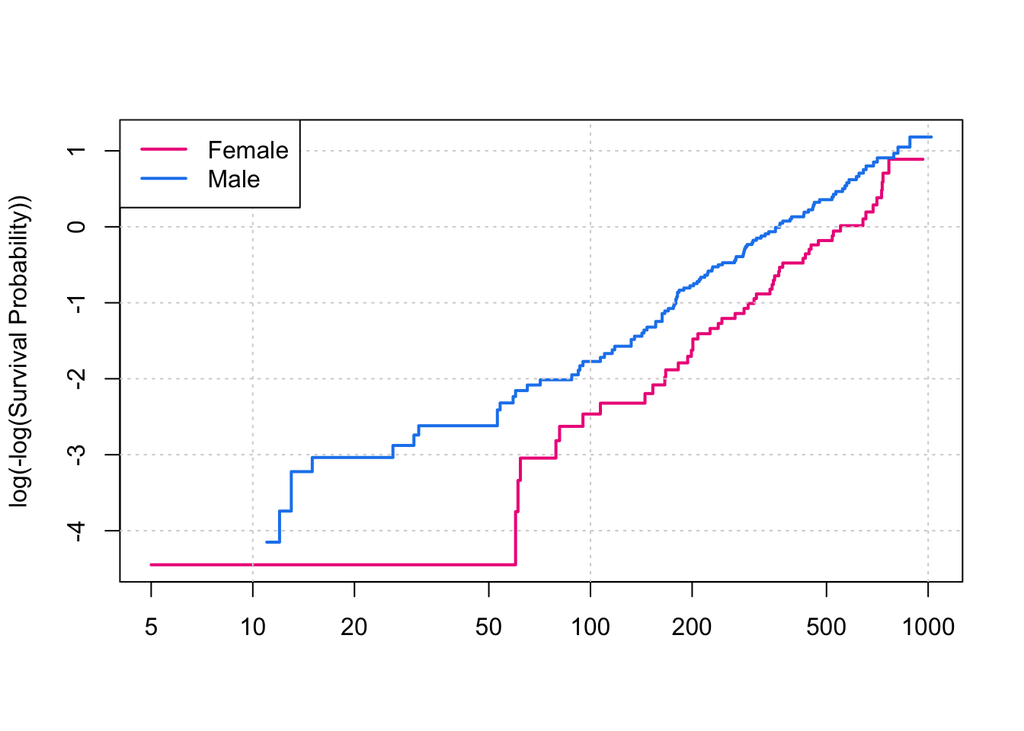

```r
plot(sex.km, fun='cloglog',
     col=c("deeppink2","dodgerblue2"), lwd=2, lty=1,
     ylab="log(-log(Survival Probability))")
grid()
legend('topleft', c("Female", "Male"),
       lty=c(1,1), lwd=c(2,2), col=c("deeppink2","dodgerblue2"))
```

Curves seem to be parallel -> PH assumption seems to be satisfied for gender.

The function `cox.zph()` in the survival package provides a convenient solution to test the proportional hazards assumption for each covariate included in a Cox regression model fit.

For each covariate, the function cox.zph() correlates the corresponding set of scaled Schoenfeld residuals with time, to test for independence between residuals and time. Additionally, it performs a global test for the model as a whole.

The proportional hazard assumption is supported by a non-significant relationship between residuals and time, and refused by a significant relationship.

Test for PH using scaled Schoenfeld test for PH

- H0: Hazards are proportional
- H1: Hazards are NOT proportional

cox.zph() return tests for each X and for the global model

```r
test.ph <- cox.zph(mod.cox)
test.ph
```

```
##             chisq df      p
## age       0.90304  1 0.3420
## sex       3.24299  1 0.0717
## ph.karno  7.98433  1 0.0047
## wt.loss   0.00382  1 0.9507
## GLOBAL   10.73439  4 0.0297
```

From the output above, the global test is statistically significant. Therefore, we can not assume the proportional hazards. In particular, the test for ph.karno is highly significant.

Plot the scaled schoenfeld residuals:

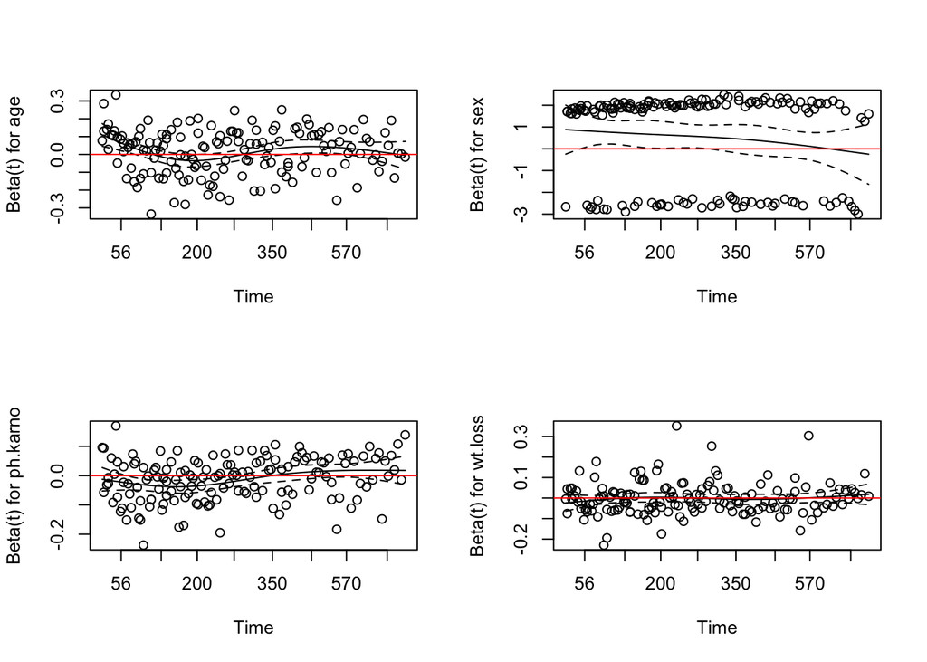

```r
par(mfrow=c(2,2))
for(i in 1:4){
  plot(test.ph[i])
  abline(h=0, col='red')
}
```

Alternatively

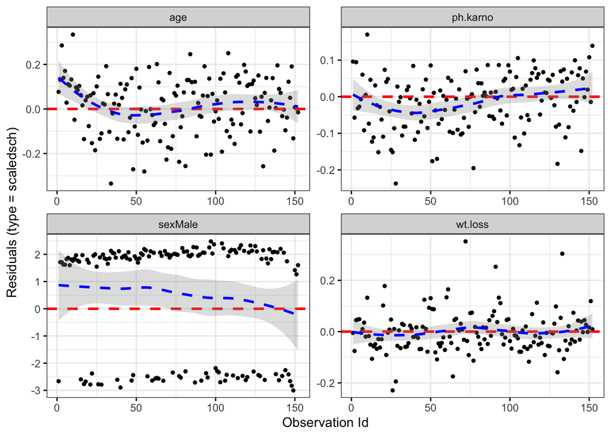

```r
ggcoxdiagnostics(mod.cox, type = "scaledsch")
```

So… What do we do? As a very basic primer on Survival Analysis we will not have time to thoroughly cover all possible solutions, we will (briefly) focus on stratification.

## Stratified Cox Model

Sometimes the proportional hazard assumption is violated for some covariate. In such cases, it is possible to stratify taking this variable into account and use the proportional hazards model in each stratum for the other covariates. We include in the model predictors that satisfy the proportional hazard assumption and remove from it the predictor that is stratified.

Now, the subjects in the $k$-th stratum have an arbitrary baseline hazard function $h_{0k}(t)$ and the effect of other explanatory variables on the hazard function can be represented by a proportional hazards model in that stratum:
$$h_{k}(t|X) = h_{0k}(t) \exp(\beta^TX)$$
with $k=1,\ldots,K$ levels of the variable that is stratified.

In the Stratified Proportional Hazards Model the regression coefficients are assumed to be the same for each stratum although the baseline hazard functions may be different and completely unrelated. The model may seem complex, but it is entirely straightforward in the likelihood framework, as we can simply combine likelihoods across strata (i.e., we multiply each strata-wise contribution). This is easily accomplished in R by using the `strata()` argument:

```r
mod.cox.strata <- coxph(Surv(time, status) ~ age + sex + strata(ph.karno) + wt.loss, data =  lung)
summary(mod.cox.strata)
```

```
## Call:
## coxph(formula = Surv(time, status) ~ age + sex + strata(ph.karno) +
##     wt.loss, data = lung)
##
##   n= 214, number of events= 152
##    (14 observations deleted due to missingness)
##
##              coef exp(coef)  se(coef)      z Pr(>|z|)
## age      0.018253  1.018421  0.010021  1.821 0.068536 .
## sexMale  0.603327  1.828190  0.180373  3.345 0.000823 ***
## wt.loss -0.005364  0.994651  0.006693 -0.801 0.422881
## ---
## Signif. codes:  0 '***' 0.001 '**' 0.01 '*' 0.05 '.' 0.1 ' ' 1
##
##         exp(coef) exp(-coef) lower .95 upper .95
## age        1.0184     0.9819    0.9986     1.039
## sexMale    1.8282     0.5470    1.2838     2.603
## wt.loss    0.9947     1.0054    0.9817     1.008
##
## Concordance= 0.615  (se = 0.028 )
## Likelihood ratio test= 15.38  on 3 df,   p=0.002
## Wald test            = 14.58  on 3 df,   p=0.002
## Score (logrank) test = 14.94  on 3 df,   p=0.002
```

Test for PH assumption

```r
test.ph.strata <- cox.zph(mod.cox.strata)
test.ph.strata
```

```
##         chisq df    p
## age     0.211  1 0.65
## sex     2.282  1 0.13
## wt.loss 0.211  1 0.65
## GLOBAL  2.780  3 0.43
```

PH assumptions are satisfied for all variables and for the global model.